# Ravens Punt Project

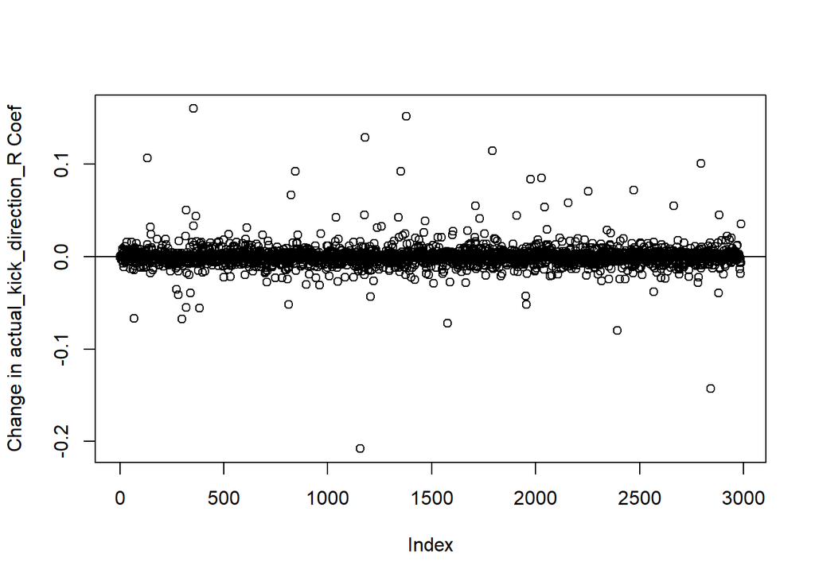

```r
plot(dfbeta(lmod)[,3],ylab="Change in actual_kick_direction_R Coef")
abline(h=0)
```

```r
influential <- dfbeta(lmod)[,3]
influential[which.max(abs(influential))]
```

```
##       1157
## -0.2078295
```

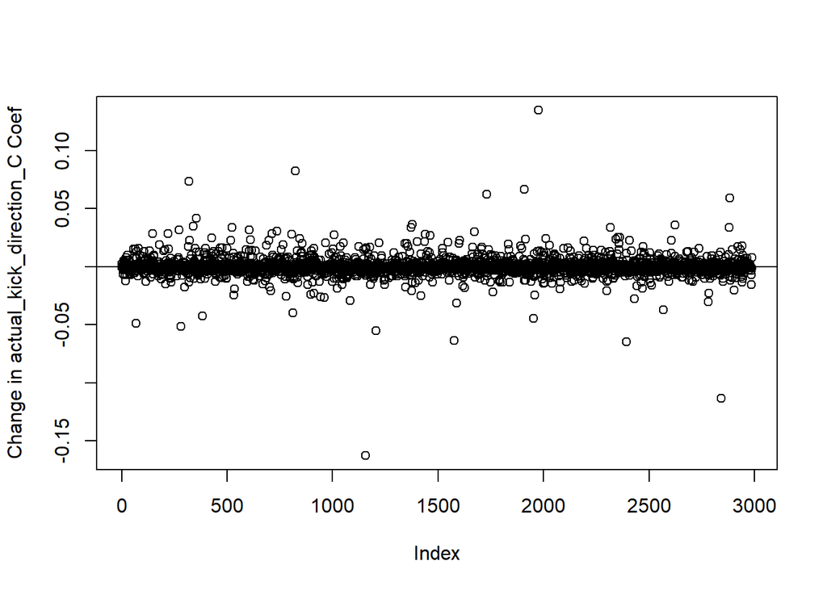

```r
plot(dfbeta(lmod)[,4],ylab="Change in actual_kick_direction_C Coef")
abline(h=0)
```

```r
influential <- dfbeta(lmod)[,4]
influential[which.max(abs(influential))]
```

```
##       1157
## -0.1626383
```

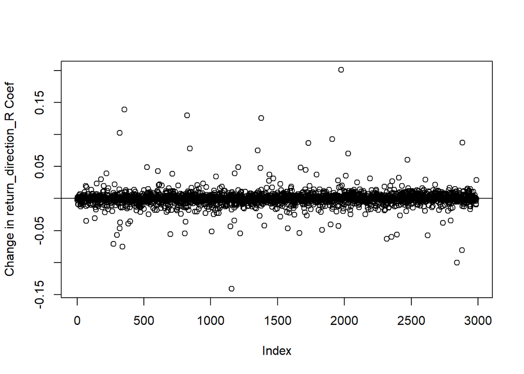

```r
plot(dfbeta(lmod)[,5],ylab="Change in return_direction_R Coef")
abline(h=0)
```

```r
influential <- dfbeta(lmod)[,5]
influential[which.max(abs(influential))]
```

```
##      1979
## 0.2008027
```

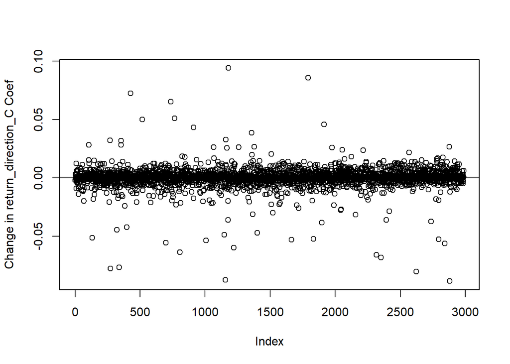

```r
plot(dfbeta(lmod)[,6],ylab="Change in return_direction_C Coef")
abline(h=0)
```

```r
influential <- dfbeta(lmod)[,6]
influential[which.max(abs(influential))]
```

```
##       1181
## 0.09397576
```

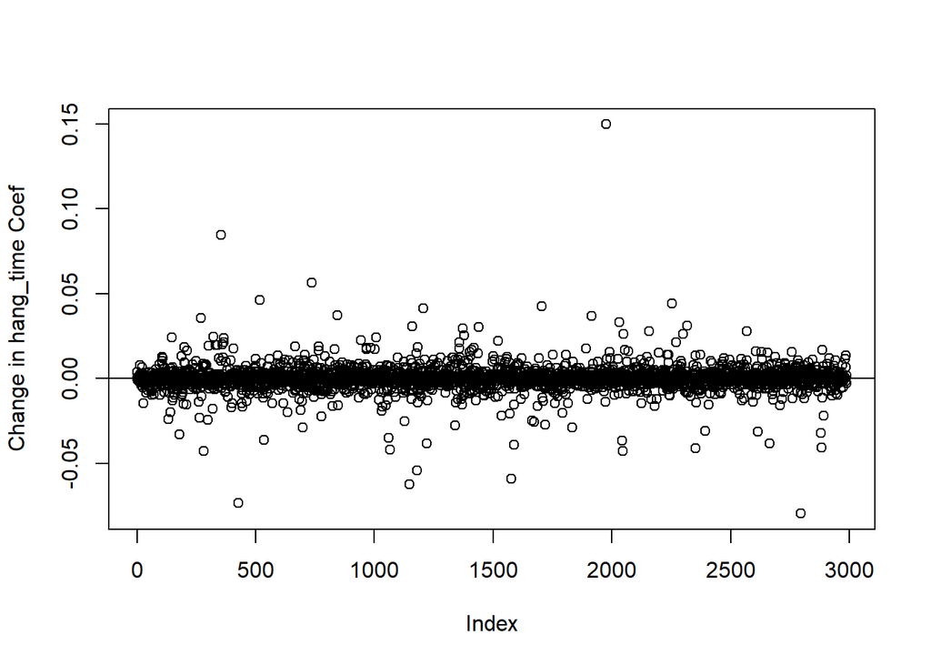

```r
plot(dfbeta(lmod)[,7],ylab="Change in hang_time Coef")
abline(h=0)
```

```r
influential <- dfbeta(lmod)[,7]
influential[which.max(abs(influential))]
```

```
##      1979
## 0.1496918
```

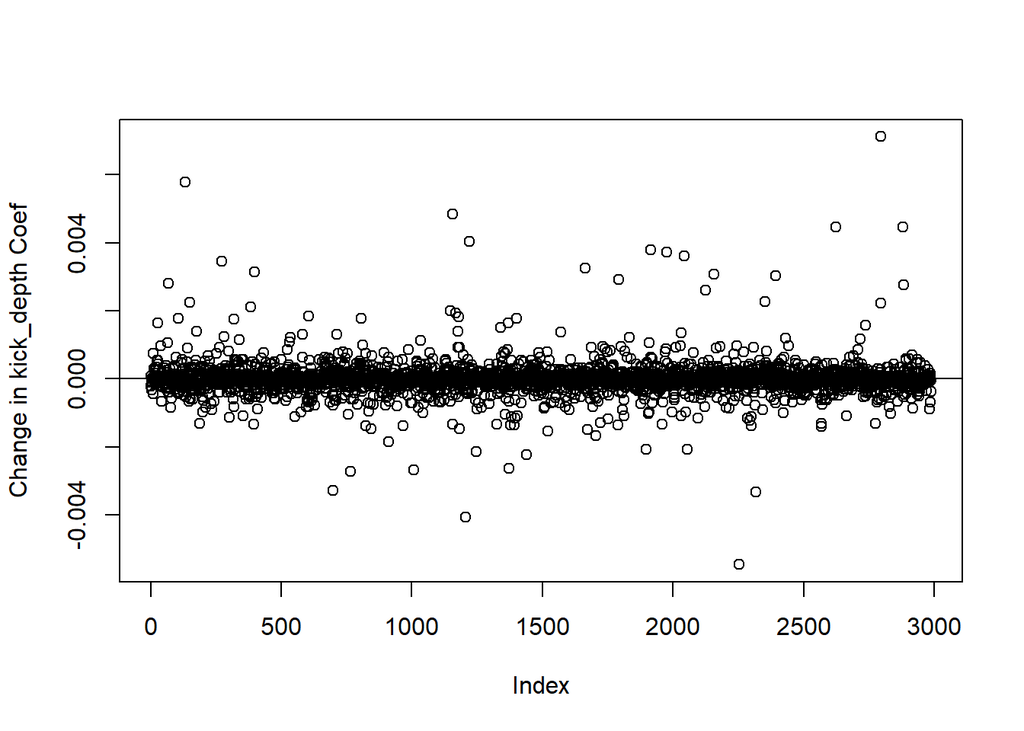

```r
plot(dfbeta(lmod)[,8],ylab="Change in kick_depth Coef")
abline(h=0)
```

```r
influential <- dfbeta(lmod)[,8]
influential[which.max(abs(influential))]
```

```
##        2798
## 0.007117713
```

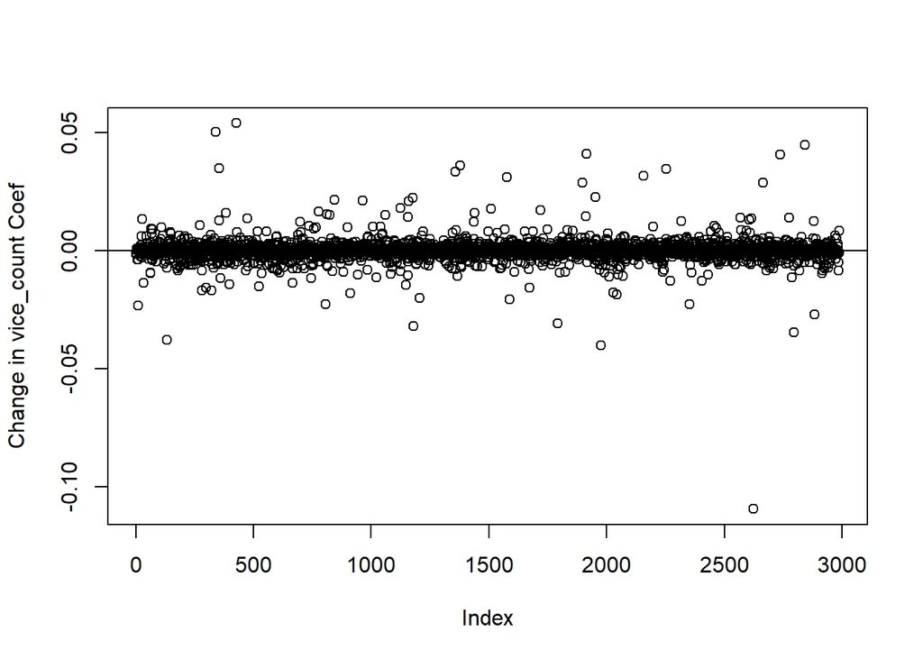

```r
plot(dfbeta(lmod)[,9],ylab="Change in vice_count Coef")
abline(h=0)
```

```r
influential <- dfbeta(lmod)[,9]
influential[which.max(abs(influential))]
```

```
##      2627
## -0.109407
```

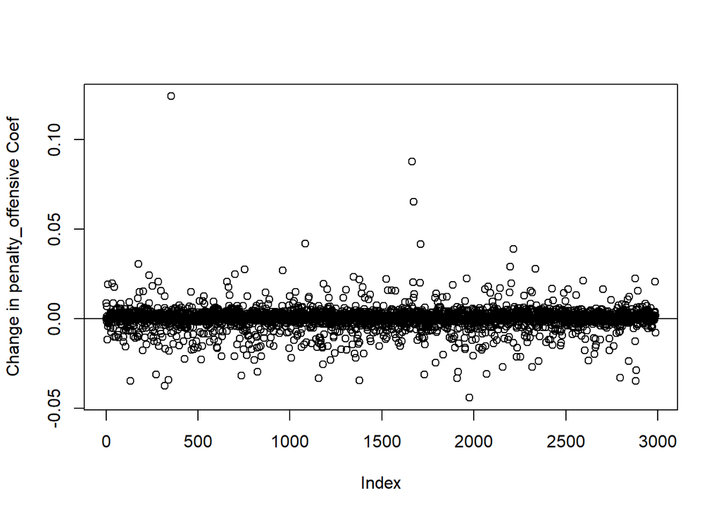

```r
plot(dfbeta(lmod)[,10],ylab="Change in penalty_offensive Coef")
abline(h=0)
```

```r
influential <- dfbeta(lmod)[,10]
influential[which.max(abs(influential))]
```

```
##       355
## 0.1239788
```

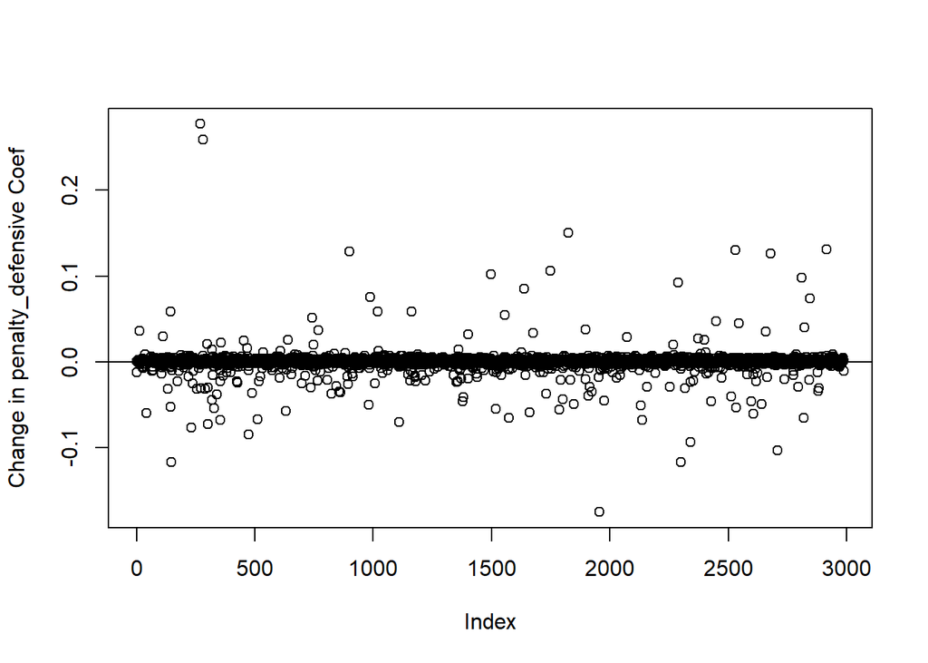

```r
plot(dfbeta(lmod)[,11],ylab="Change in penalty_defensive Coef")
abline(h=0)
```

```r
influential <- sort(dfbeta(lmod)[,11], decreasing = F)
tail(influential, 1)
```

```
##       270
## 0.2772372
```

```r
head(tail(influential, 2),1)
```

```
##       282
## 0.2594507
```

```r
finalLmodAllu<-lm(return_yards ~ clean_catch_binary + actual_kick_direction_R + actual_kick_direction_C + return_direction_R + return_direction_C + hang_time + kick_depth + vise_count + penalty_offensive + penalty_defensive, puntOrig, subset=(row.names(puntOrig)!="1979" & row.names(puntOrig)!="2627" & row.names(puntOrig)!="355" & row.names(puntOrig)!="270" & row.names(puntOrig)!="282" ))
summary(finalLmodAllu)
```

```
##
## Call:
## lm(formula = return_yards ~ clean_catch_binary + actual_kick_direction_R +
##     actual_kick_direction_C + return_direction_R + return_direction_C +
##     hang_time + kick_depth + vise_count + penalty_offensive +
##     penalty_defensive, data = puntOrig, subset = (row.names(puntOrig) !=
##     "1979" & row.names(puntOrig) != "2627" & row.names(puntOrig) !=
##     "355" & row.names(puntOrig) != "270" & row.names(puntOrig) !=
##     "282"))
##
## Residuals:
##     Min      1Q  Median      3Q     Max
## -25.686  -5.130  -1.407   2.753  82.379
##
## Coefficients:
##                         Estimate Std. Error t value Pr(>|t|)
## (Intercept)              0.69396    1.80906   0.384  0.70130
## clean_catch_binary       4.34653    0.52986   8.203 3.45e-16 ***
## actual_kick_direction_R  2.31165    0.58619   3.943 8.22e-05 ***
## actual_kick_direction_C  2.77335    0.46994   5.902 4.01e-09 ***
## return_direction_R       3.02578    0.48370   6.255 4.53e-10 ***
## return_direction_C      -0.43107    0.42448  -1.016  0.30994
## hang_time               -3.85873    0.44149  -8.740  < 2e-16 ***
## kick_depth               0.33565    0.02757  12.176  < 2e-16 ***
## vise_count               0.74563    0.22920   3.253  0.00115 **
## penalty_offensive       -5.45817    0.47081 -11.593  < 2e-16 ***
## penalty_defensive       -2.49719    0.89197  -2.800  0.00515 **
## ---
## Signif. codes:  0 '***' 0.001 '**' 0.01 '*' 0.05 '.' 0.1 ' ' 1
##
## Residual standard error: 9.426 on 2972 degrees of freedom
##   (3 observations deleted due to missingness)
## Multiple R-squared:  0.1468, Adjusted R-squared:  0.1439
## F-statistic: 51.14 on 10 and 2972 DF,  p-value: < 2.2e-16
```

After the tests and removing outliars/influential points we are left with the model above.

```r
min(puntOrig$return_yards)
```

```
## [1] -14
```

```r
finalLmodAllu<-lm(1/(return_yards-(-1+min(puntOrig$return_yards))) ~ clean_catch_binary + actual_kick_direction_R + actual_kick_direction_C + return_direction_R + return_direction_C + hang_time + kick_depth + vise_count + penalty_offensive + penalty_defensive, puntOrig, subset=(row.names(puntOrig)!="1979" & row.names(puntOrig)!="2627" & row.names(puntOrig)!="355" & row.names(puntOrig)!="270" & row.names(puntOrig)!="282" & row.names(puntOrig)!="298"), na.action = na.exclude)
summary(finalLmodAllu)
```

```
##
## Call:
## lm(formula = 1/(return_yards - (-1 + min(puntOrig$return_yards))) ~
##     clean_catch_binary + actual_kick_direction_R + actual_kick_direction_C +
##         return_direction_R + return_direction_C + hang_time +
##         kick_depth + vise_count + penalty_offensive + penalty_defensive,
##     data = puntOrig, subset = (row.names(puntOrig) != "1979" &
##         row.names(puntOrig) != "2627" & row.names(puntOrig) !=
##         "355" & row.names(puntOrig) != "270" & row.names(puntOrig) !=
##         "282" & row.names(puntOrig) != "298"), na.action = na.exclude)
##
## Residuals:
##       Min        1Q    Median        3Q       Max
## -0.041634 -0.008883 -0.000781  0.007967  0.192694
##
## Coefficients:
##                           Estimate Std. Error t value Pr(>|t|)
## (Intercept)              5.993e-02  2.866e-03  20.912  < 2e-16 ***
## clean_catch_binary      -9.616e-03  8.391e-04 -11.460  < 2e-16 ***
## actual_kick_direction_R -4.011e-03  9.291e-04  -4.317 1.63e-05 ***
## actual_kick_direction_C -4.199e-03  7.443e-04  -5.641 1.85e-08 ***
## return_direction_R      -8.033e-03  7.667e-04 -10.478  < 2e-16 ***
## return_direction_C      -2.036e-03  6.722e-04  -3.028  0.00248 **
## hang_time                7.533e-03  6.993e-04  10.772  < 2e-16 ***
## kick_depth              -6.011e-04  4.366e-05 -13.769  < 2e-16 ***
## vise_count              -3.871e-04  3.631e-04  -1.066  0.28648
## penalty_offensive        9.621e-03  7.456e-04  12.903  < 2e-16 ***
## penalty_defensive        3.857e-03  1.413e-03   2.730  0.00637 **
## ---
## Signif. codes:  0 '***' 0.001 '**' 0.01 '*' 0.05 '.' 0.1 ' ' 1
##
## Residual standard error: 0.01493 on 2971 degrees of freedom
##   (3 observations deleted due to missingness)
## Multiple R-squared:  0.2072, Adjusted R-squared:  0.2046
## F-statistic: 77.66 on 10 and 2971 DF,  p-value: < 2.2e-16
```

```r
lmodu<-finalLmodAllu
```

We then perform a transformation similar to the ones we had already done. With the new tranformation we check out assumptions again, just as we had done previously.

```r
residuals(lmodu)[which.max(abs(residuals(lmodu)))]
```

```
##      2072
## 0.1926944
```

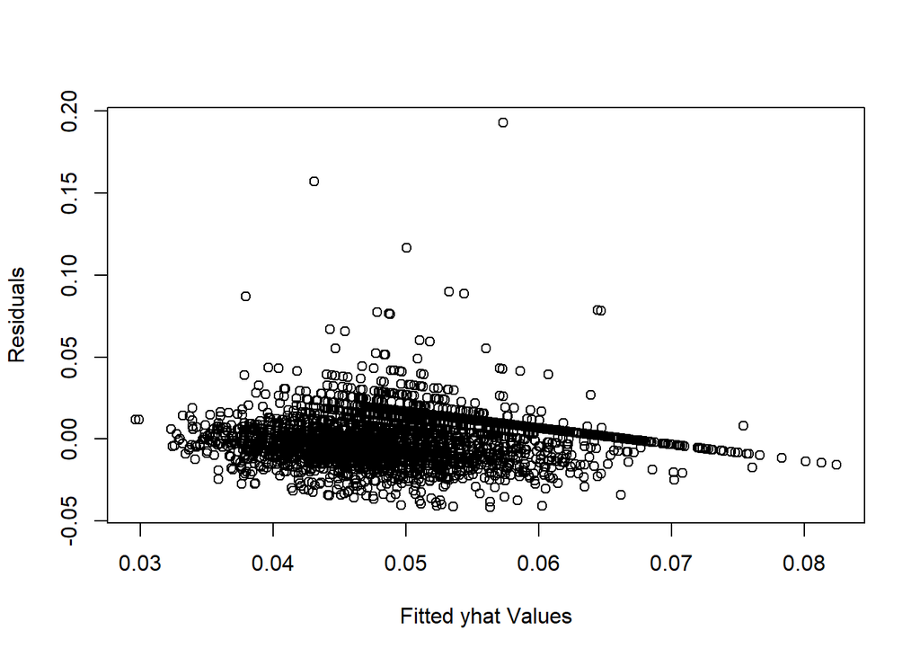

```r
plot(fitted(lmodu), residuals(lmodu), xlab = "Fitted yhat Values", ylab = "Residuals")
```

```r
var.test(residuals(lmodu)[fitted(lmod)>0.0475], residuals(lmodu)[fitted(lmod) < 0.0475])
```

```
##
##  F test to compare two variances
##
## data:  residuals(lmodu)[fitted(lmod) > 0.0475] and residuals(lmodu)[fitted(lmod) < 0.0475]
## F = 1.6509, num df = 2885, denom df = 95, p-value = 0.001914
## alternative hypothesis: true ratio of variances is not equal to 1
## 95 percent confidence interval:
##  1.210307 2.163795
## sample estimates:
## ratio of variances
##           1.650854
```

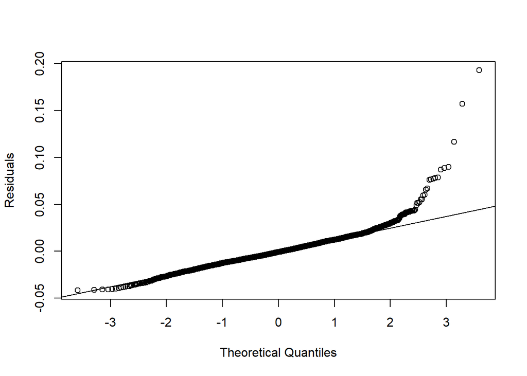

```r
qqnorm(residuals(lmodu), ylab="Residuals", main="")
qqline(residuals(lmodu))
```

```r
shapiro.test(residuals(lmodu))
```

```
##
##  Shapiro-Wilk normality test
##
## data:  residuals(lmodu)
## W = 0.90559, p-value < 2.2e-16
```

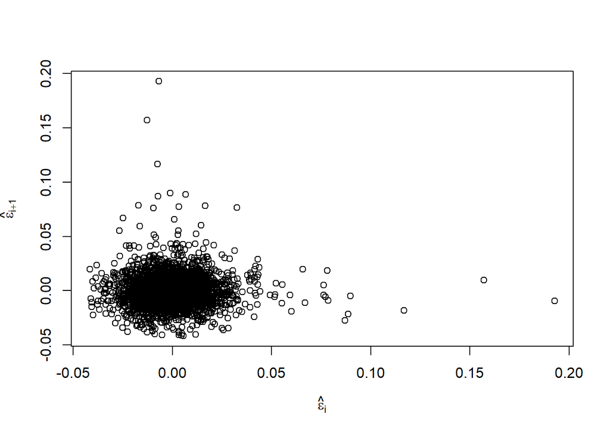

```r
n<-length(residuals(lmodu))
plot(tail(residuals(lmodu), n-1) ~ head(residuals(lmodu),n-1), xlab = expression(hat(epsilon)[i]), ylab = expression(hat(epsilon)[i+1]))
```

```r
library(lmtest)
dwtest((1/(return_yards-(-1+min(puntOrig$return_yards)))) ~ clean_catch_binary + actual_kick_direction_R + actual_kick_direction_C + return_direction_R + return_direction_C + hang_time + kick_depth + vise_count + penalty_offensive + penalty_defensive, data=puntOrig)
```

```
##
##  Durbin-Watson test
##
## data:  (1/(return_yards - (-1 + min(puntOrig$return_yards)))) ~ clean_catch_binary +     actual_kick_direction_R + actual_kick_direction_C + return_direction_R +     return_direction_C + hang_time + kick_depth + vise_count +     penalty_offensive + penalty_defensive
## DW = 1.9804, p-value = 0.2942
## alternative hypothesis: true autocorrelation is greater than 0
```

```r
puntOrig <- puntOrig[-c(1979, 2627, 355, 270, 282, 298) ,]
puntOrig$residuals <- residuals(lmodu)
unique<-unique(puntOrig$offense_team_id)
puntOrig<-subset(puntOrig, (!is.na(residuals)) & (!is.na(defense_team_id)))
```

We now look at the same sets of histograms but this time with the combined penalty/no penalty model and reach the same conclusions. No team performs significantly better or worse then others on punt returns in the NFL.

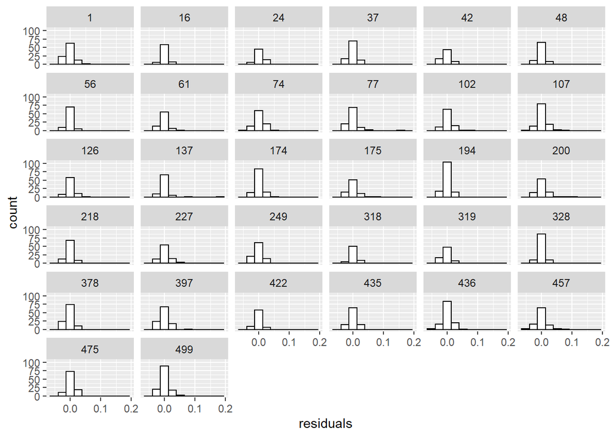

```r
ggplot(puntOrig, aes(x = residuals)) +
  geom_histogram(fill = "white", colour = "black", bins = 10) +
  facet_wrap(offense_team_id ~ .)
```

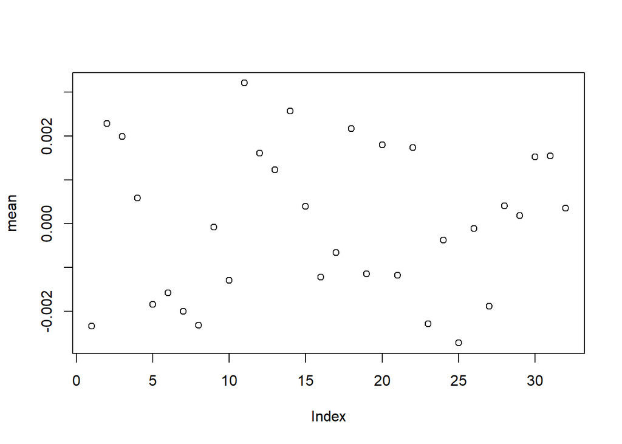

```r
mean <- tapply(puntOrig$residuals, puntOrig$offense_team_id, mean)
plot(mean)
```

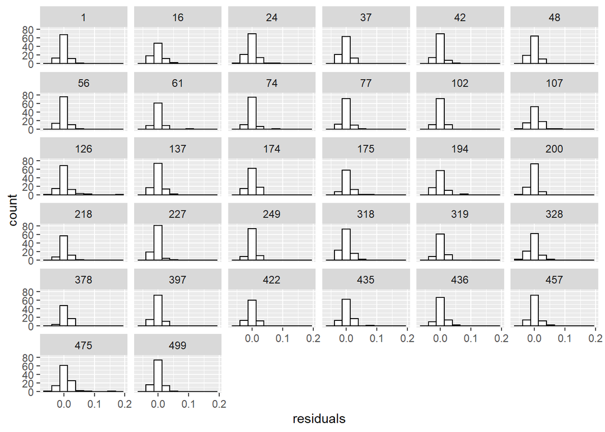

```r
ggplot(puntOrig, aes(x = residuals)) +
  geom_histogram(fill = "white", colour = "black", bins = 10) +
  facet_wrap(defense_team_id ~ .)
```

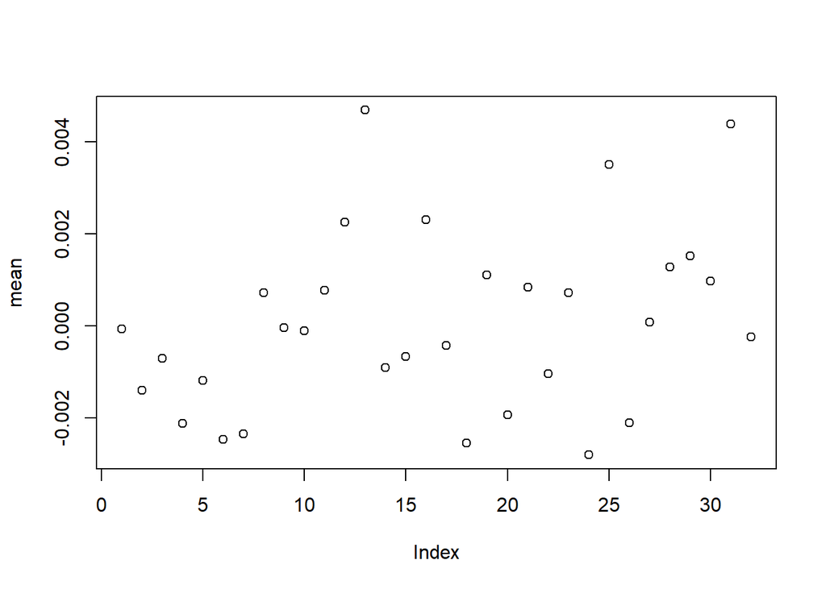

```r
mean <- tapply(puntOrig$residuals, puntOrig$defense_team_id, mean)
plot(mean)
```